# Wildlight Portrait Studio: Analytics Findings

Independent portfolio case study using synthetic data inspired by common photography-business workflows.

Anders Jewel

August 01, 2026

> **Ethics statement.** This report uses entirely synthetic records for the fictional Wildlight Portrait Studio. It contains no real employer, client, financial, or personal data.

# Executive summary

The synthetic dataset records **$638,507 in cash revenue**, **$177,620 in operating expenses**, and **$460,887 in gross profit**. Average booking value is **$857**. The lead-to-booking conversion rate is **50%**, the repeat-client rate is **33.1%**, cancellations are **7.7%**, and open balances total **$132,583**.

# Revenue and seasonal demand

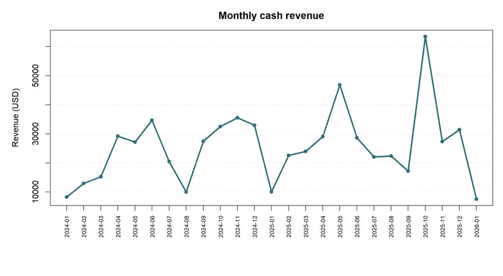

October–November and graduation-season demand peaks are visible, while January is consistently softer. The final January 2026 point represents late-December inquiries booked after year-end; it is not a full operating month.

# Package performance and profitability

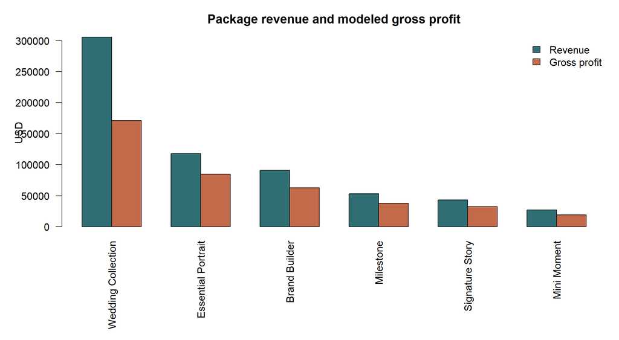

Wedding Collection is the revenue and gross-profit leader. Essential Portrait is the strongest non-wedding package by revenue, while Brand Builder contributes a strong modeled profit at lower booking volume.

# Marketing-source performance

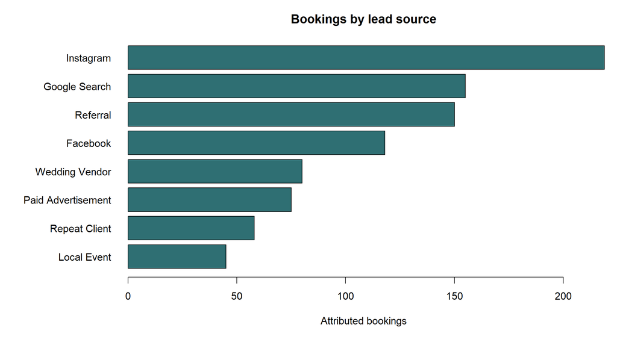

Instagram contributes the most attributed bookings and revenue, followed by Google Search and Referral. Allocation decisions should also include channel spend; the synthetic dataset supports attributed performance but not a complete return-on-ad-spend calculation.

# Client retention

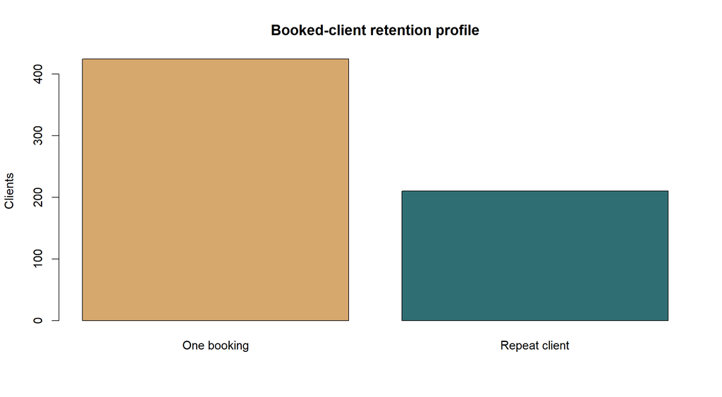

The repeat-client rate is 33.1%. A fictional studio could test post-delivery follow-ups, milestone reminders, and referral incentives while monitoring contribution margin rather than repeat count alone.

# Operations and payments

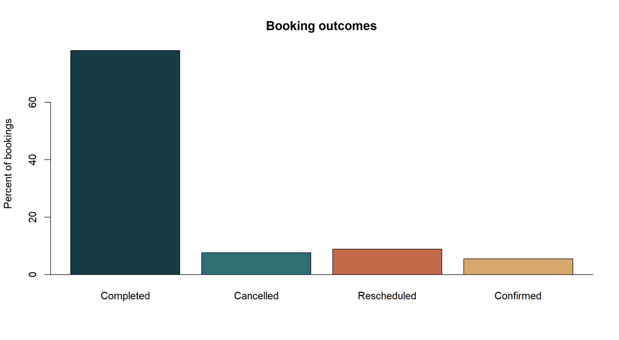

Average first response time is 36.7 hours and average inquiry-to-booking time is 12.3 days. Open balances total $132,583. The analysis suggests a response-time service level, required deposits, automated invoice reminders, and daily exception queues.

# Forecasting perspective

The forecast is a seasonal-trend baseline for planning, not a production prediction. Two synthetic years do not support high-confidence inference or a robust out-of-sample evaluation.

# Recommendations

1. Respond to new inquiries within one business day and surface SLA exceptions daily.
2. Require a deposit and agreement before confirmation; automate balance reminders.
3. Plan staffing and campaigns ahead of April–May and October–November demand.
4. Preserve Wedding Collection as the premium anchor while testing portrait and branding bundles.
5. Evaluate marketing channels using conversion, attributed revenue, and spend—not lead volume alone.
6. Add cancellation/reschedule reasons and labor-hour costs to improve root-cause and margin analysis.

# Reproducibility and limitations

This R Markdown report reads the same processed CSVs used by Python, SQL, Excel, Power BI, and Tableau assets. Package variable costs are simplified and do not represent full job costing. Source attribution is single-touch. No recommendation is claimed to have been implemented by a real organization.